← Home

# Extended Station Redundancy Analysis

**Companion report to the main Network Analysis.**

This notebook extends the temperature-only redundancy result in the main report with five additional perspectives:

1. **Multivariate redundancy** — correlation, clustering, and scatter analysis across the four FWI core inputs (temperature, RH, wind, rain) plus all six FWI output codes (FFMC, DMC, DC, ISI, BUI, FWI).
2. **Extreme-event correlation** — agreement between stations during 95th/99th percentile conditions and fire-weather days (FWI ≥ 15), where consistency matters most.
3. **Leave-one-out (LOO) degradation** — for each station, recompute the network's FWI chain with that station's contributions to cross-station imputation removed; measure how much the remaining stations' values change. A station whose removal causes large LOO degradation is *load-bearing* for the network and should not be decommissioned.
4. **Block-bootstrap 95% confidence intervals** (10 000 iterations, 24-hour blocks) on every pairwise correlation reported in the main analysis.
5. **Partial correlation** controlling for Stanhope (residualisation) to distinguish *direct* station-to-station relationships from *both-being-driven-by-regional-weather* relationships.

**How this report is rendered.** The figures shown below were generated during the original run of this notebook (commit `e638648`, 2026-04-05) and have been recovered from git history. The notebook code is preserved as-is so the analysis can be re-executed against fresh data; the recovered figures are embedded directly into each cell so this report is readable without re-running it.

**Audience:** technical reviewers and anyone who wants the multivariate / LOO evidence behind the main report's removal recommendation.

# Station Redundancy Analysis

Pairwise correlation, PCA, hierarchical clustering, and stanhope benchmarking across all 6 PEINP/ECCC stations for four core meteorological variables.

**Stations**: cavendish, greenwich, north_rustico, stanhope (ECCC), stanley_bridge, tracadie

```
Loaded 152489 rows across 6 stations
Date range: 2023-04-01 -> 2026-03-24
```

```
  Air Temperature: 26113 hours, PC1=0.963
```

```
  Relative Humidity: 26113 hours, PC1=0.793
```

```
  Wind Speed: 26113 hours, PC1=0.709
```

```
  Precipitation: 26113 hours, PC1=0.547
Done.
```

## 1. Correlation Heatmaps

Pairwise Pearson correlation for each variable across all 6 stations. Values close to 1.0 indicate redundant signals; values < 0.7 indicate independent information.

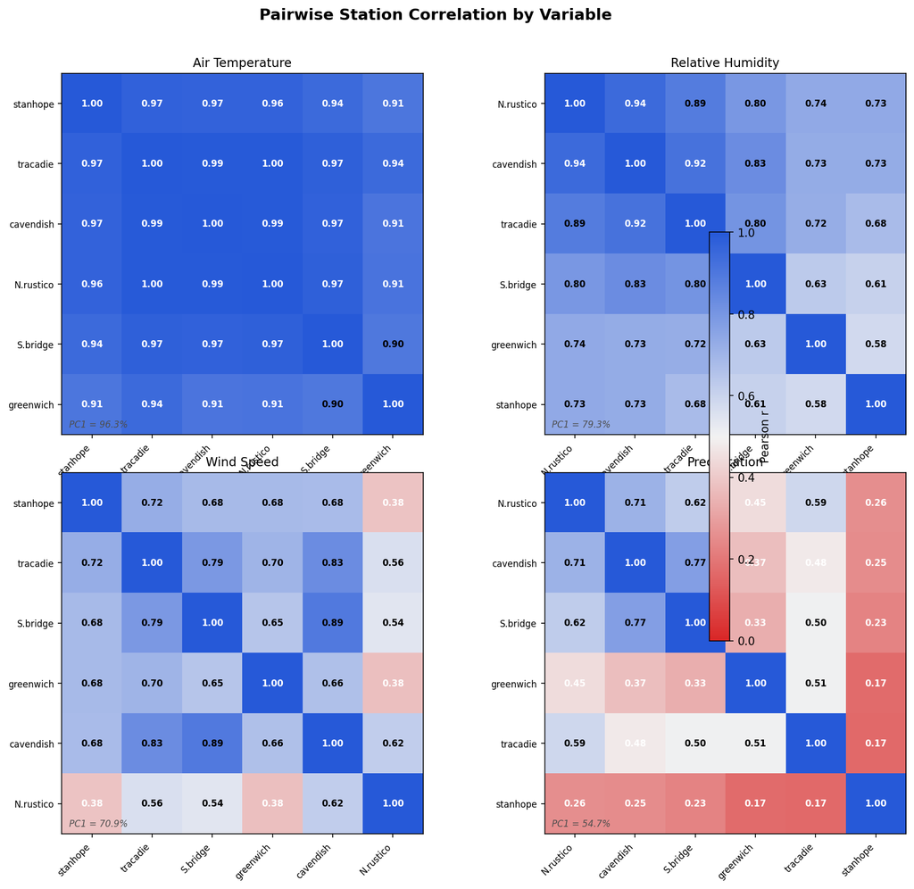

## 2. Hierarchical Clustering Dendrograms

Agglomerative clustering (average linkage) on distance = 1 - r. Stations that merge early are the most redundant.

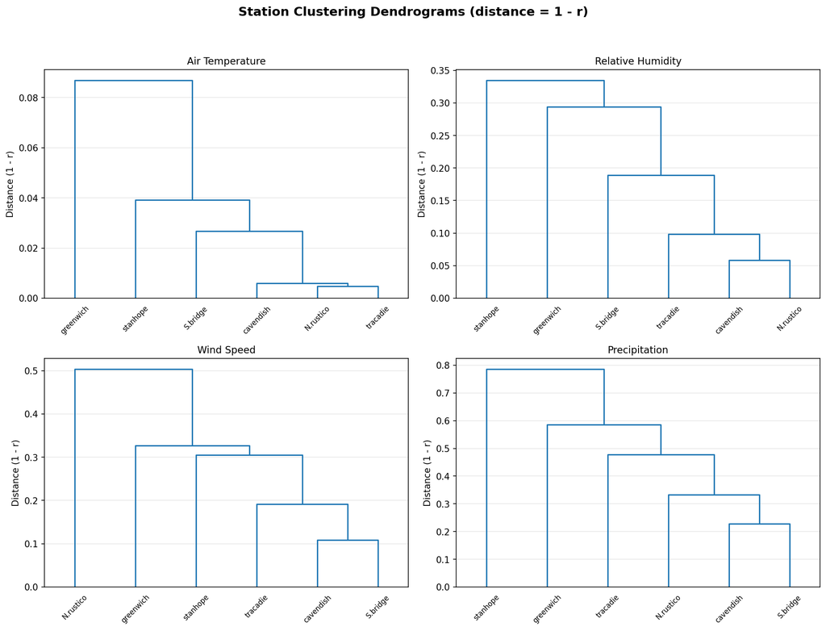

## 3. Temperature Scatter - The Tight Cluster

Cavendish, north rustico, and tracadie have pairwise r >= 0.994 for temperature. These scatter plots show how tightly coupled they are.

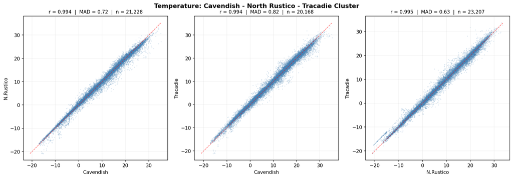

## 4. Temperature Scatter - All Stations vs Stanhope

Every PEINP station plotted against the ECCC stanhope reference.

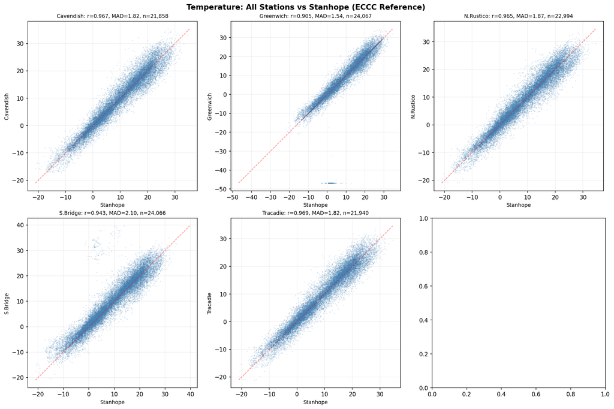

## 5. Stanhope Benchmark - Mean Absolute Difference

How far each station deviates from stanhope on average, per variable.

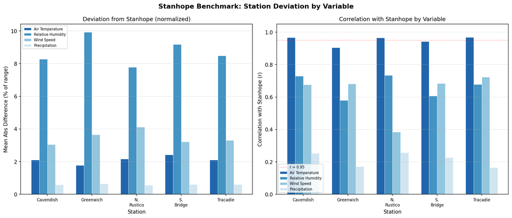

## 6. Summary: Recommendation Matrix

Keep/remove/defer recommendation per station per variable, with risk band from uncertainty quantification.

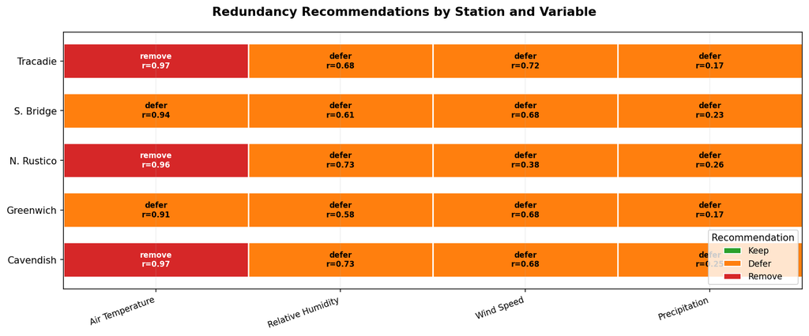

## 8. Bootstrap Confidence Intervals on Correlations

Block bootstrap (24-hour blocks, 10 000 iterations) to quantify uncertainty around each pairwise Pearson *r*. Stations whose lower 95% CI stays above the 0.95 removal threshold are *confidently* redundant.

```
  Air Temperat       cavendish vs       greenwich: r=0.930  95% CI=[0.895, 0.964]  no
```

```
  Air Temperat       cavendish vs   north_rustico: r=0.995  95% CI=[0.994, 0.995]  YES
```

```
  Air Temperat       cavendish vs        stanhope: r=0.969  95% CI=[0.966, 0.972]  YES
```

```
  Air Temperat       cavendish vs  stanley_bridge: r=0.968  95% CI=[0.947, 0.987]  no
```

```
  Air Temperat       cavendish vs        tracadie: r=0.994  95% CI=[0.993, 0.994]  YES
```

```
  Air Temperat       greenwich vs   north_rustico: r=0.929  95% CI=[0.892, 0.964]  no
```

```
  Air Temperat       greenwich vs        stanhope: r=0.920  95% CI=[0.884, 0.953]  no
```

```
  Air Temperat       greenwich vs  stanley_bridge: r=0.904  95% CI=[0.864, 0.942]  no
```

```
  Air Temperat       greenwich vs        tracadie: r=0.930  95% CI=[0.893, 0.964]  no
```

```
  Air Temperat   north_rustico vs        stanhope: r=0.966  95% CI=[0.963, 0.969]  YES
```

```
  Air Temperat   north_rustico vs  stanley_bridge: r=0.966  95% CI=[0.944, 0.985]  no
```

```
  Air Temperat   north_rustico vs        tracadie: r=0.994  95% CI=[0.994, 0.995]  YES
```

```
  Air Temperat        stanhope vs  stanley_bridge: r=0.939  95% CI=[0.917, 0.957]  no
```

```
  Air Temperat        stanhope vs        tracadie: r=0.968  95% CI=[0.965, 0.970]  YES
```

```
  Air Temperat  stanley_bridge vs        tracadie: r=0.965  95% CI=[0.943, 0.984]  no
```

```
  Relative Hum       cavendish vs       greenwich: r=0.733  95% CI=[0.641, 0.824]  no
```

```
  Relative Hum       cavendish vs   north_rustico: r=0.949  95% CI=[0.942, 0.955]  no
```

```
  Relative Hum       cavendish vs        stanhope: r=0.717  95% CI=[0.698, 0.736]  no
```

```
  Relative Hum       cavendish vs  stanley_bridge: r=0.804  95% CI=[0.729, 0.877]  no
```

```
  Relative Hum       cavendish vs        tracadie: r=0.928  95% CI=[0.920, 0.935]  no
```

```
  Relative Hum       greenwich vs   north_rustico: r=0.737  95% CI=[0.647, 0.823]  no
```

```
  Relative Hum       greenwich vs        stanhope: r=0.581  95% CI=[0.504, 0.652]  no
```

```
  Relative Hum       greenwich vs  stanley_bridge: r=0.588  95% CI=[0.494, 0.686]  no
```

```
  Relative Hum       greenwich vs        tracadie: r=0.703  95% CI=[0.614, 0.787]  no
```

```
  Relative Hum   north_rustico vs        stanhope: r=0.734  95% CI=[0.716, 0.751]  no
```

```
  Relative Hum   north_rustico vs  stanley_bridge: r=0.772  95% CI=[0.698, 0.840]  no
```

```
  Relative Hum   north_rustico vs        tracadie: r=0.896  95% CI=[0.885, 0.906]  no
```

```
  Relative Hum        stanhope vs  stanley_bridge: r=0.589  95% CI=[0.523, 0.650]  no
```

```
  Relative Hum        stanhope vs        tracadie: r=0.673  95% CI=[0.649, 0.695]  no
```

```
  Relative Hum  stanley_bridge vs        tracadie: r=0.784  95% CI=[0.711, 0.852]  no
```

```
  Wind Speed         cavendish vs       greenwich: r=0.664  95% CI=[0.633, 0.693]  no
```

```
  Wind Speed         cavendish vs   north_rustico: r=0.581  95% CI=[0.522, 0.638]  no
```

```
  Wind Speed         cavendish vs        stanhope: r=0.683  95% CI=[0.658, 0.707]  no
```

```
  Wind Speed         cavendish vs  stanley_bridge: r=0.876  95% CI=[0.864, 0.888]  no
```

```
  Wind Speed         cavendish vs        tracadie: r=0.823  95% CI=[0.806, 0.839]  no
```

```
  Wind Speed         greenwich vs   north_rustico: r=0.344  95% CI=[0.263, 0.433]  no
```

```
  Wind Speed         greenwich vs        stanhope: r=0.687  95% CI=[0.651, 0.724]  no
```

```
  Wind Speed         greenwich vs  stanley_bridge: r=0.647  95% CI=[0.610, 0.682]  no
```

```
  Wind Speed         greenwich vs        tracadie: r=0.699  95% CI=[0.669, 0.726]  no
```

```
  Wind Speed     north_rustico vs        stanhope: r=0.367  95% CI=[0.305, 0.433]  no
```

```
  Wind Speed     north_rustico vs  stanley_bridge: r=0.497  95% CI=[0.439, 0.554]  no
```

```
  Wind Speed     north_rustico vs        tracadie: r=0.536  95% CI=[0.481, 0.593]  no
```

```
  Wind Speed          stanhope vs  stanley_bridge: r=0.691  95% CI=[0.659, 0.722]  no
```

```
  Wind Speed          stanhope vs        tracadie: r=0.724  95% CI=[0.698, 0.747]  no
```

```
  Wind Speed    stanley_bridge vs        tracadie: r=0.780  95% CI=[0.756, 0.803]  no
```

```
  Precipitatio       cavendish vs       greenwich: r=0.355  95% CI=[0.285, 0.434]  no
```

```
  Precipitatio       cavendish vs   north_rustico: r=0.699  95% CI=[0.599, 0.790]  no
```

```
  Precipitatio       cavendish vs        stanhope: r=0.240  95% CI=[0.178, 0.313]  no
```

```
  Precipitatio       cavendish vs  stanley_bridge: r=0.811  95% CI=[0.757, 0.861]  no
```

```
  Precipitatio       cavendish vs        tracadie: r=0.479  95% CI=[0.398, 0.563]  no
```

```
  Precipitatio       greenwich vs   north_rustico: r=0.437  95% CI=[0.371, 0.503]  no
```

```
  Precipitatio       greenwich vs        stanhope: r=0.161  95% CI=[0.111, 0.217]  no
```

```
  Precipitatio       greenwich vs  stanley_bridge: r=0.339  95% CI=[0.276, 0.410]  no
```

```
  Precipitatio       greenwich vs        tracadie: r=0.507  95% CI=[0.423, 0.593]  no
```

```
  Precipitatio   north_rustico vs        stanhope: r=0.248  95% CI=[0.172, 0.340]  no
```

```
  Precipitatio   north_rustico vs  stanley_bridge: r=0.658  95% CI=[0.601, 0.722]  no
```

```
  Precipitatio   north_rustico vs        tracadie: r=0.589  95% CI=[0.505, 0.667]  no
```

```
  Precipitatio        stanhope vs  stanley_bridge: r=0.234  95% CI=[0.185, 0.287]  no
```

```
  Precipitatio        stanhope vs        tracadie: r=0.166  95% CI=[0.117, 0.225]  no
```

```
  Precipitatio  stanley_bridge vs        tracadie: r=0.504  95% CI=[0.436, 0.578]  no
Bootstrap complete.
```

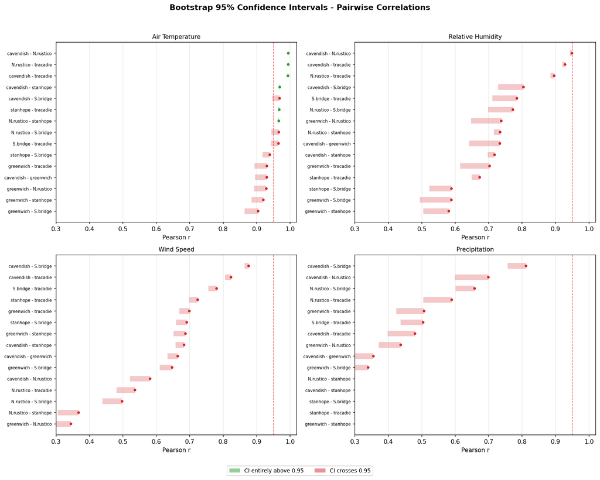

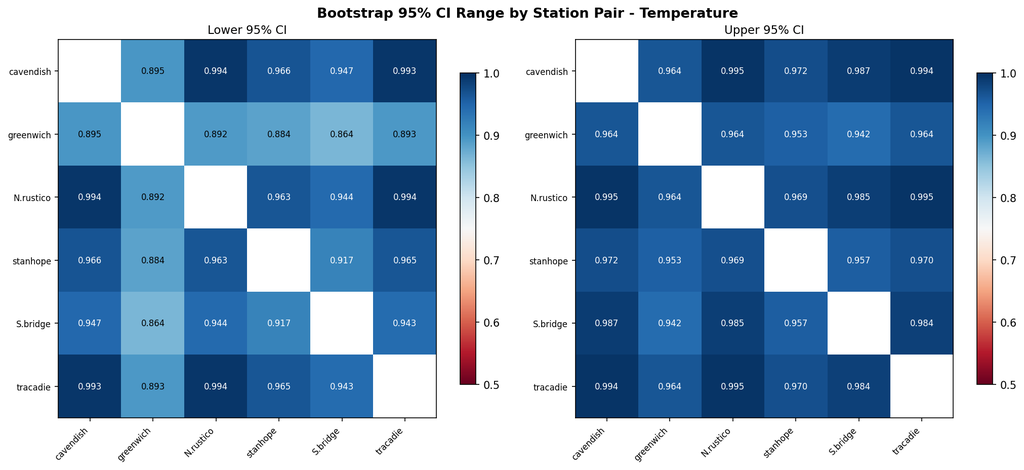

## 9. Partial Correlation - Controlling for Stanhope

Strips out the shared regional weather signal by conditioning on stanhope (the ECCC reference). If partial *r* collapses, stations merely share an airmass; if it stays high, they are genuinely locally redundant.

```
  Air Temperat       cavendish vs       greenwich: marginal=0.907  partial=0.321  reg_dep=64.6%
  Air Temperat       cavendish vs   north_rustico: marginal=0.994  partial=0.914  reg_dep=8.0%
  Air Temperat       cavendish vs  stanley_bridge: marginal=0.972  partial=0.718  reg_dep=26.1%
  Air Temperat       cavendish vs        tracadie: marginal=0.994  partial=0.897  reg_dep=9.8%
  Air Temperat       greenwich vs   north_rustico: marginal=0.914  partial=0.321  reg_dep=64.8%
  Air Temperat       greenwich vs  stanley_bridge: marginal=0.898  partial=0.261  reg_dep=71.0%
  Air Temperat       greenwich vs        tracadie: marginal=0.942  partial=0.410  reg_dep=56.5%
  Air Temperat   north_rustico vs  stanley_bridge: marginal=0.974  partial=0.690  reg_dep=29.2%
  Air Temperat   north_rustico vs        tracadie: marginal=0.995  partial=0.915  reg_dep=8.1%
  Air Temperat  stanley_bridge vs        tracadie: marginal=0.974  partial=0.669  reg_dep=31.3%
  Relative Hum       cavendish vs       greenwich: marginal=0.729  partial=0.550  reg_dep=24.5%
  Relative Hum       cavendish vs   north_rustico: marginal=0.942  partial=0.874  reg_dep=7.2%
  Relative Hum       cavendish vs  stanley_bridge: marginal=0.832  partial=0.715  reg_dep=14.0%
  Relative Hum       cavendish vs        tracadie: marginal=0.917  partial=0.841  reg_dep=8.3%
  Relative Hum       greenwich vs   north_rustico: marginal=0.737  partial=0.558  reg_dep=24.2%
  Relative Hum       greenwich vs  stanley_bridge: marginal=0.632  partial=0.424  reg_dep=32.8%
  Relative Hum       greenwich vs        tracadie: marginal=0.725  partial=0.540  reg_dep=25.5%
  Relative Hum   north_rustico vs  stanley_bridge: marginal=0.796  partial=0.649  reg_dep=18.5%
  Relative Hum   north_rustico vs        tracadie: marginal=0.886  partial=0.777  reg_dep=12.3%
  Relative Hum  stanley_bridge vs        tracadie: marginal=0.805  partial=0.670  reg_dep=16.7%
  Wind Speed         cavendish vs       greenwich: marginal=0.662  partial=0.370  reg_dep=44.2%
  Wind Speed         cavendish vs   north_rustico: marginal=0.620  partial=0.483  reg_dep=22.1%
  Wind Speed         cavendish vs  stanley_bridge: marginal=0.891  partial=0.780  reg_dep=12.4%
  Wind Speed         cavendish vs        tracadie: marginal=0.828  partial=0.653  reg_dep=21.2%
  Wind Speed         greenwich vs   north_rustico: marginal=0.377  partial=0.152  reg_dep=59.6%
  Wind Speed         greenwich vs  stanley_bridge: marginal=0.647  partial=0.333  reg_dep=48.6%
  Wind Speed         greenwich vs        tracadie: marginal=0.702  partial=0.402  reg_dep=42.8%
  Wind Speed     north_rustico vs  stanley_bridge: marginal=0.542  partial=0.363  reg_dep=33.1%
  Wind Speed     north_rustico vs        tracadie: marginal=0.561  partial=0.421  reg_dep=24.9%
  Wind Speed    stanley_bridge vs        tracadie: marginal=0.789  partial=0.562  reg_dep=28.8%
  Precipitatio       cavendish vs       greenwich: marginal=0.372  partial=0.343  reg_dep=7.9%
  Precipitatio       cavendish vs   north_rustico: marginal=0.709  partial=0.689  reg_dep=2.9%
  Precipitatio       cavendish vs  stanley_bridge: marginal=0.771  partial=0.761  reg_dep=1.4%
  Precipitatio       cavendish vs        tracadie: marginal=0.478  partial=0.460  reg_dep=3.8%
  Precipitatio       greenwich vs   north_rustico: marginal=0.449  partial=0.424  reg_dep=5.5%
  Precipitatio       greenwich vs  stanley_bridge: marginal=0.332  partial=0.306  reg_dep=7.8%
  Precipitatio       greenwich vs        tracadie: marginal=0.506  partial=0.493  reg_dep=2.6%
  Precipitatio   north_rustico vs  stanley_bridge: marginal=0.624  partial=0.605  reg_dep=3.2%
  Precipitatio   north_rustico vs        tracadie: marginal=0.586  partial=0.574  reg_dep=2.1%
  Precipitatio  stanley_bridge vs        tracadie: marginal=0.504  partial=0.485  reg_dep=3.8%
Partial correlation complete.
```

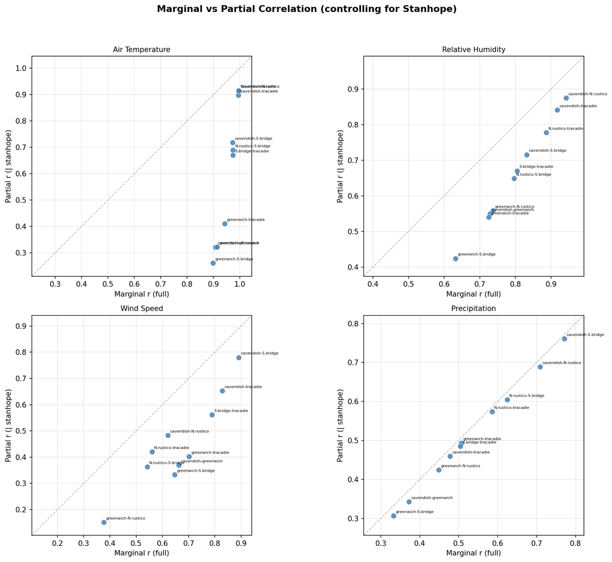

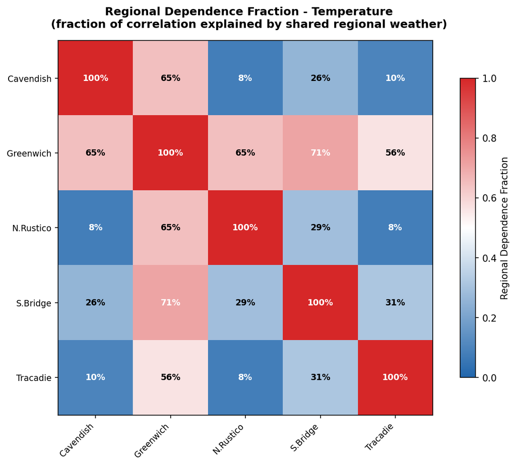

## 10. Extreme Event Correlation

Stations agree on calm days - the real question is whether they agree when conditions are dangerous. Correlation is computed only on hours where **either** station exceeds the 95th or 99th percentile. FWI fire-weather days (FWI >= 15, FWI >= 25) are analysed separately.

```
FWI data loaded: 152489 rows across 6 stations
```

```
Extreme correlation computed: 210 pairs.
variable           percentile
Air Temperature    95th         -0.803835
                   99th         -1.070063
FFMC               FWI>=15      -0.055471
                   FWI>=25      -0.103207
FWI                FWI>=15      -0.791045
                   FWI>=25      -1.139844
ISI                FWI>=15      -0.847521
                   FWI>=25            NaN
Precipitation      95th         -0.214687
                   99th         -0.540212
Relative Humidity  95th         -0.980790
                   99th         -1.008797
Wind Speed         95th         -0.707902
                   99th         -0.928183
```

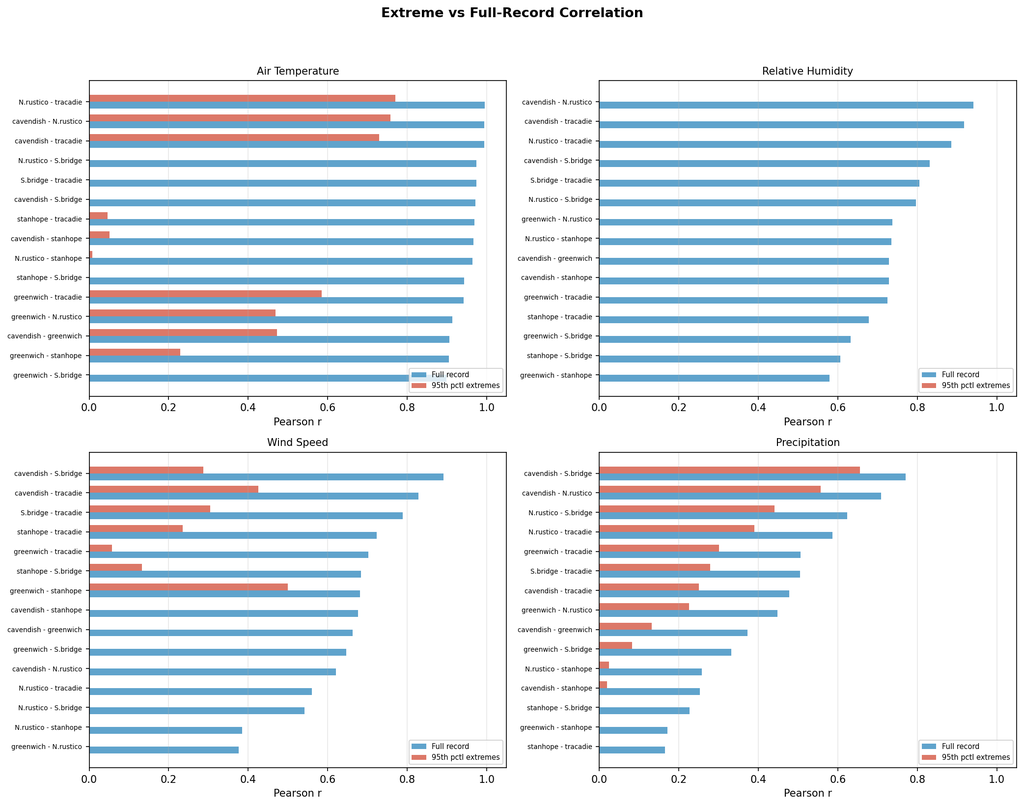

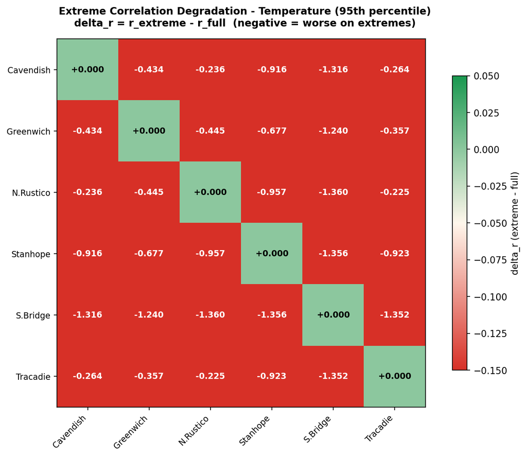

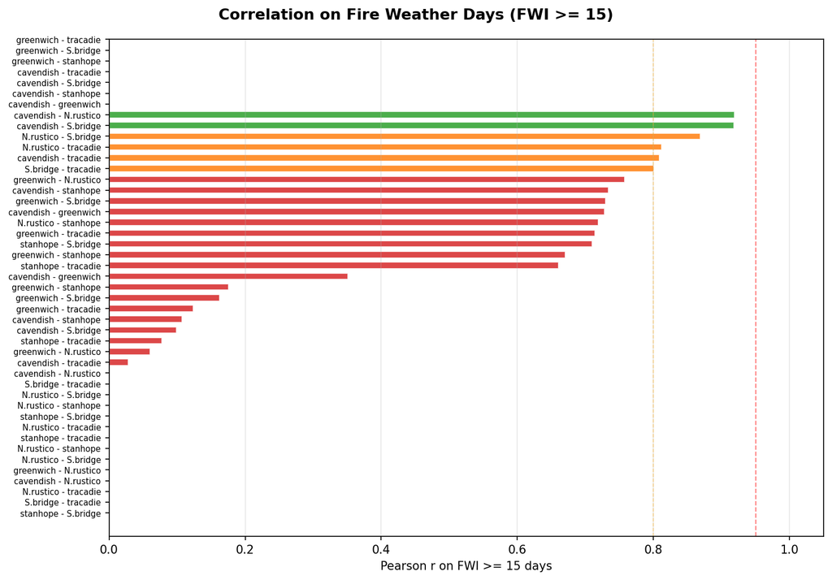

## 11. FWI-Component Redundancy

Run the full correlation / PCA / clustering suite on the six FWI outputs (FFMC, DMC, DC, ISI, BUI, FWI) instead of raw meteorological inputs. DC and DMC are daily-integrated (slow response) and should cluster tightly; FFMC is hourly (fast response) and may diverge more.

```
  FFMC: 26093 hours, PC1=0.854
  DMC : 26110 hours, PC1=0.932
  DC  : 26110 hours, PC1=0.967
```

```
  ISI : 26090 hours, PC1=0.661
  BUI : 26090 hours, PC1=0.943
  FWI : 26090 hours, PC1=0.872
FWI component analysis complete.
```

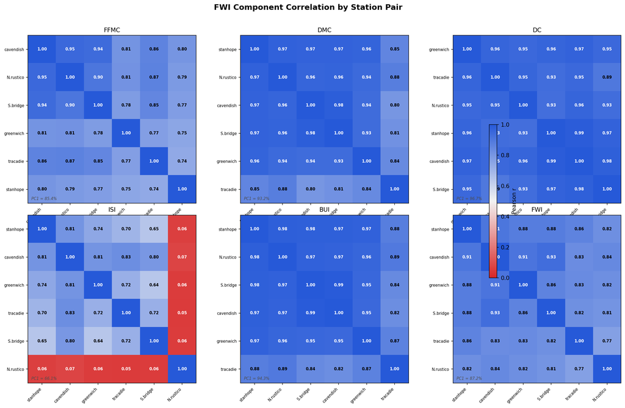

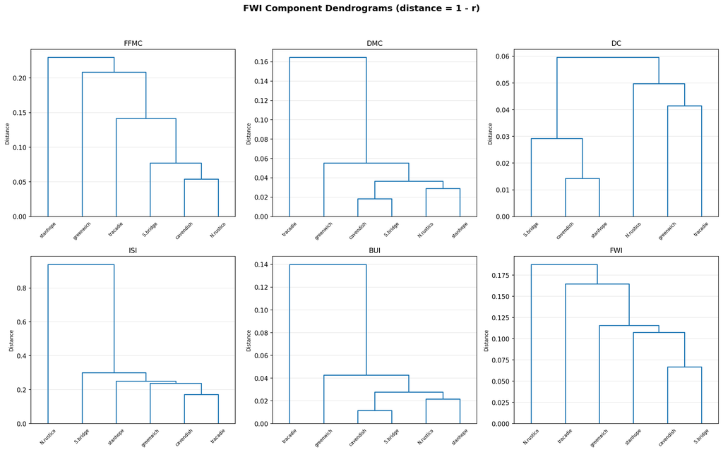

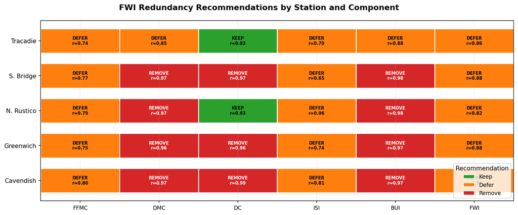

## 12. Leave-One-Out FWI Degradation

The most direct redundancy test: identify which rows in each station's hourly data were cross-station imputed from a given donor, then measure how much FWI changes when that donor is removed. Stations whose removal causes < 1 FWI point MAE across the network are redundant.

```
Donor trace summary:
               total_rows fwi_non_null    fwi_pct air_temperature_c_imputed wind_speed_kmh_imputed relative_humidity_pct_imputed
cavendish           26092        22193  85.056722                         0                   3890                             0
greenwich           26092        21470  82.285758                     10158                   3249                          4229
north_rustico       26113        24947  95.534791                         0                   1188                             0
stanhope            24144        23081   95.59725                         0                      0                             0
stanley_bridge      26092        21563  82.642189                      4486                   8371                         26092
tracadie            23956        20771  86.704792                      3076                   3809                         23956
```

```
--- Removing: cavendish ---
```

```
  -> north_rustico: 2 rows, 0 with FWI, MAE upper=0.00
```

```
  -> stanley_bridge: 24600 rows, 20072 with FWI, MAE upper=2.65
```

```
  -> tracadie: 18672 rows, 18559 with FWI, MAE upper=3.57
--- Removing: greenwich ---
```

```
--- Removing: north_rustico ---
  -> cavendish: 3890 rows, 104 with FWI, MAE upper=0.41
  -> greenwich: 5 rows, 2 with FWI, MAE upper=7.72
```

```
  -> stanley_bridge: 3789 rows, 2211 with FWI, MAE upper=0.58
  -> tracadie: 5938 rows, 2827 with FWI, MAE upper=0.83
--- Removing: stanley_bridge ---
```

```
--- Removing: tracadie ---
```

```
Leave-one-out summary:
           removed          target  n_affected_rows  n_affected_fwi  mae_upper_bound
0        cavendish       greenwich                0               0         0.000000
1        cavendish   north_rustico                2               0         0.000000
2        cavendish        stanhope                0               0         0.000000
3        cavendish  stanley_bridge            24600           20072         2.647056
4        cavendish        tracadie            18672           18559         3.571283
5        greenwich       cavendish                0               0         0.000000
6        greenwich   north_rustico                0               0         0.000000
7        greenwich        stanhope                0               0         0.000000
8        greenwich  stanley_bridge                0               0         0.000000
9        greenwich        tracadie                0               0         0.000000
10   north_rustico       cavendish             3890             104         0.410253
11   north_rustico       greenwich                5               2         7.722071
12   north_rustico        stanhope                0               0         0.000000
13   north_rustico  stanley_bridge             3789            2211         0.579859
14   north_rustico        tracadie             5938            2827         0.827372
15  stanley_bridge       cavendish                0               0         0.000000
16  stanley_bridge       greenwich                0               0         0.000000
17  stanley_bridge   north_rustico                0               0         0.000000
18  stanley_bridge        stanhope                0               0         0.000000
19  stanley_bridge        tracadie                0               0         0.000000
20        tracadie       cavendish                0               0         0.000000
21        tracadie       greenwich                0               0         0.000000
22        tracadie   north_rustico                0               0         0.000000
23        tracadie        stanhope                0               0         0.000000
24        tracadie  stanley_bridge                0               0         0.000000
```

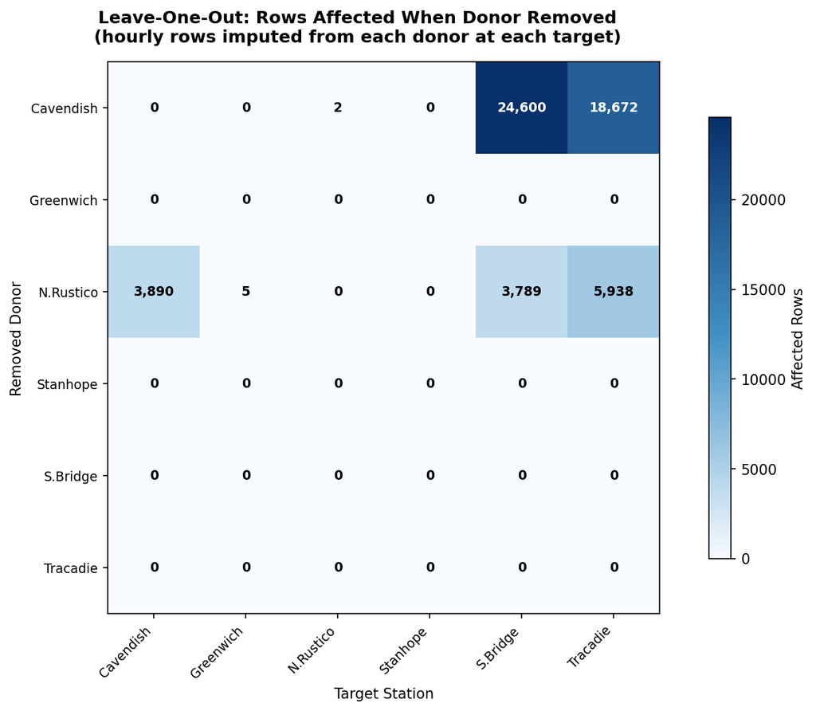

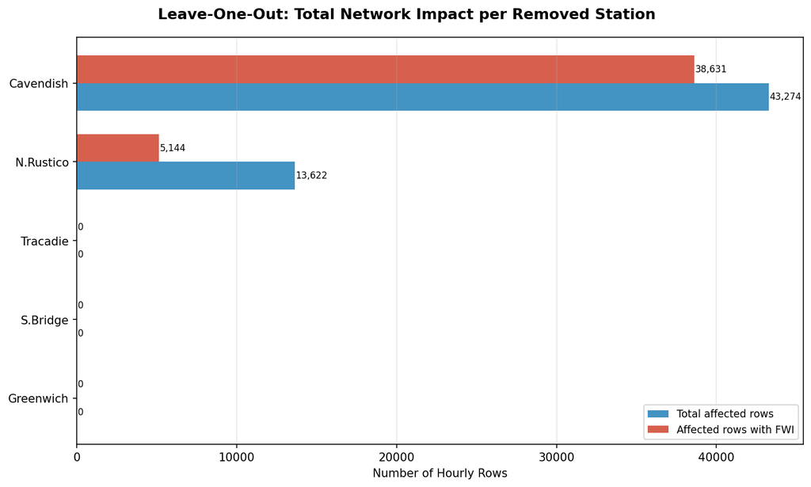

**Back to:** Project landing page · Network Analysis · FWI Map Dashboard